# lab3task

## Goal:

The goal of the report is to train our models using linear regression. We will be training models for following variables:

- median income
- population
- number of households
- median house value

```python
import pandas as pd
import seaborn as sns
import matplotlib.pyplot as plt
from sklearn import linear_model
from sklearn.metrics import mean_absolute_error, mean_squared_error
```

## Getting the Data

Link to the [housing data source](https://www.kaggle.com/datasets/camnugent/california-housing-prices) on kaggle

```python
df = pd.read_csv('./data/housing/housing.csv')
```

## Exploratory Data Analysis (EDA):

```python
df.describe()
```

|  | longitude | latitude | housing_median_age | total_rooms | total_bedrooms | population | households | median_income | median_house_value |
| --- | --- | --- | --- | --- | --- | --- | --- | --- | --- |
| count | 20,640.00 | 20,640.00 | 20,640.00 | 20,640.00 | 20,433.00 | 20,640.00 | 20,640.00 | 20,640.00 | 20,640.00 |
| mean | -119.57 | 35.63 | 28.64 | 2,635.76 | 537.87 | 1,425.48 | 499.54 | 3.87 | 206,855.82 |
| std | 2.00 | 2.14 | 12.59 | 2,181.62 | 421.39 | 1,132.46 | 382.33 | 1.90 | 115,395.62 |
| min | -124.35 | 32.54 | 1.00 | 2.00 | 1.00 | 3.00 | 1.00 | 0.50 | 14,999.00 |
| 25% | -121.80 | 33.93 | 18.00 | 1,447.75 | 296.00 | 787.00 | 280.00 | 2.56 | 119,600.00 |
| 50% | -118.49 | 34.26 | 29.00 | 2,127.00 | 435.00 | 1,166.00 | 409.00 | 3.53 | 179,700.00 |
| 75% | -118.01 | 37.71 | 37.00 | 3,148.00 | 647.00 | 1,725.00 | 605.00 | 4.74 | 264,725.00 |
| max | -114.31 | 41.95 | 52.00 | 39,320.00 | 6,445.00 | 35,682.00 | 6,082.00 | 15.00 | 500,001.00 |

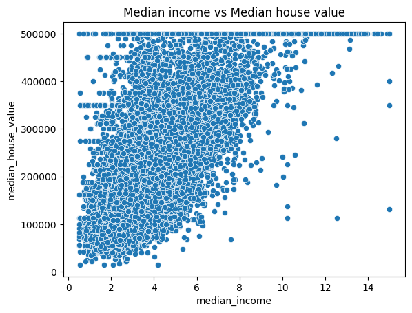

```python
sns.scatterplot(x="median_income", y="median_house_value", data = df).set_title("Median income vs Median house value")
```

### Graph 1 Review (Median income vs Median house value):

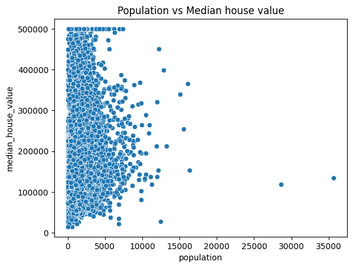

```python
sns.scatterplot(x="population", y="median_house_value", data = df).set_title("Population vs Median house value")
```

### Graph 2 Review (Population vs Median house value):

We can see in graph that:

- In population column there are 2 values specifically that are too much greater than the other observations. These data points may be considered as the outliers
- The population of California dataset taken is less than 17,000 (excluding the outliers)

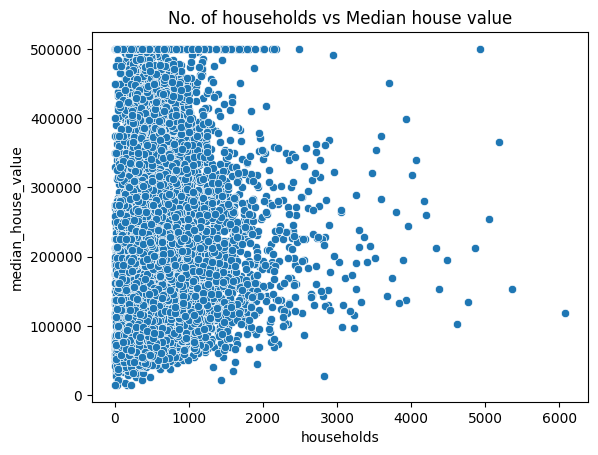

```python
sns.scatterplot(x="households", y="median_house_value", data = df).set_title("No. of households vs Median house value")
```

### Graph 3 Review (Households vs Median house value):

- Most number of households lie within the range of 0-3500
- In this graph also, we can see that all median house values that might be greater than 500,000 are limited to 500,000

## Linear Regression:

```python
model1 = linear_model.LinearRegression()
```

```python
model1.fit(X = df[["median_income"]], y = df[["median_house_value"]])
```

```
LinearRegression()
```

```python
mae1 = mean_absolute_error(df[["median_house_value"]], model1.predict(X = df[["median_income"]]))
mse1 = mean_squared_error(df[["median_house_value"]], model1.predict(X = df[["median_income"]]))
```

```python
model2 = linear_model.LinearRegression()
```

```python
model2.fit(X = df[["population"]], y = df[["median_house_value"]])
```

```
LinearRegression()
```

```python
mae2 = mean_absolute_error(df[["median_house_value"]], model2.predict(X = df[["population"]]))
mse2 = mean_squared_error(df[["median_house_value"]], model2.predict(X = df[["population"]]))
```

```python
model3 = linear_model.LinearRegression()
```

```python
model3.fit(X = df[["households"]], y = df[["median_house_value"]])
```

```
LinearRegression()
```

```python
mae3 = mean_absolute_error(df[["median_house_value"]], model3.predict(X = df[["households"]]))
mse3 = mean_squared_error(df[["median_house_value"]], model3.predict(X = df[["households"]]))
```

```python
data = {
    "Intercept" : [model1.intercept_, model2.intercept_, model3.intercept_],
    "Slope" : [model1.coef_, model2.coef_, model3.coef_],
    "MAE" : [mae1, mae2, mae3],
    "MSE" : [mse1, mse2, mse3]

}

tb = pd.DataFrame(data, index= ["Model1", "Model2", "Model3"])

print(tb)
```

```
                   Intercept                   Slope       MAE
Model1    [45085.5767032679]  [[41793.849201896286]] 62,625.93  \
Model2  [210436.26207627333]  [[-2.511752774615085]] 91,153.82
Model3  [196928.57716233088]  [[19.872775155643875]] 90,802.74

                     MSE
Model1  7,011,311,502.93
Model2 13,307,412,412.39
Model3 13,257,776,904.73
```

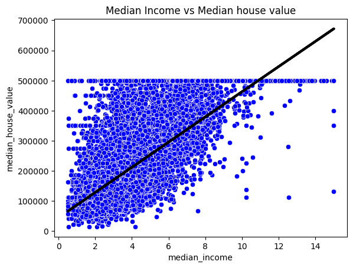

```python
sns.scatterplot(x='median_income', y='median_house_value', data = df, color='blue').set_title("Median Income vs Median house value")
plt.plot(df[["median_income"]], model1.predict(df[["median_income"]]), color = 'black', linewidth=3)
plt.show()
```

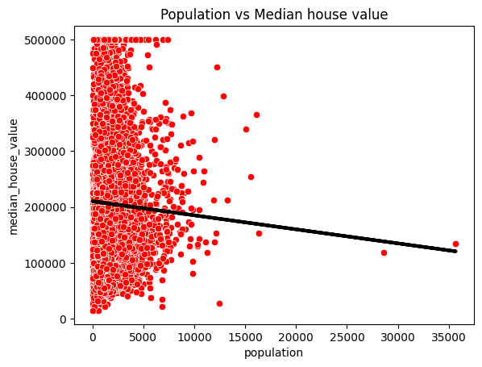

```python
sns.scatterplot(x='population', y='median_house_value', data = df, color='red').set_title("Population vs Median house value")
plt.plot(df[["population"]], model2.predict(df[["population"]]), color = 'black', linewidth=3)
plt.show()
```

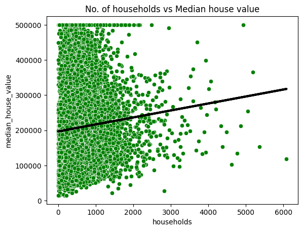

```python
sns.scatterplot(x='households', y='median_house_value', data = df, color='green').set_title("No. of households vs Median house value")
plt.plot(df[["households"]], model3.predict(df[["households"]]), color = 'black', linewidth=3)
plt.show()
```